# Exploratory Data Analysis

Mathews Philip Venattu

31/05/2021

##Reading Data Using read RDS for getting the data from a rds file format. Created a copy of original variable

```r
data_Wider<-readRDS('../Full_Data_Wider.rds', refhook = NULL)
bs_data<-read.csv('../Data/bow_shock_only_Data.csv')
short_Data<-readRDS('../Average_Data.rds', refhook = NULL)

joined_data<-readRDS('../Data/joined_data.rds', refhook = NULL)
data_copy<-data_Wider
events_data<-na.omit(data_copy,cols=c("type_cross"))
bs_avgData<-na.omit(short_Data,cols=c("type_cross"))
```

## Showing all Data

### Short Data Variable(short_data)

It contains the columns that represents th average of 15 minutes before and 15 minutes after each event occurs

```r
head(short_Data)
```

```
##                 TimeStamp   X_KSM    Y_KSM    Z_KSM     B_Tot         BX
## 1 01/01/2005 00:14:30.000 1172434 -3390218 220057.5 0.4496983 -0.1084797
## 2 01/01/2005 00:15:30.000 1172492 -3390186 220087.8 0.4477490 -0.1139399
## 3 01/01/2005 00:16:30.000 1172551 -3390154 220118.0 0.4473423 -0.1282609
## 4 01/01/2005 00:17:30.000 1172610 -3390121 220148.2 0.4475818 -0.1304609
## 5 01/01/2005 00:18:30.000 1172669 -3390089 220178.4 0.4514222 -0.1315351
## 6 01/01/2005 00:19:30.000 1172727 -3390057 220208.6 0.4593824 -0.1196326
##           BY         BZ type_cross dirn_cross Avg_Lag_Bx Avg_Lag_By Avg_Lag_Bz
## 1 -0.3970490 -0.1754911       <NA>       <NA> -0.1089951 -0.3825424 -0.1954832
## 2 -0.3934928 -0.1769947       <NA>       <NA> -0.1085519 -0.3835528 -0.1932570
## 3 -0.3818776 -0.1935436       <NA>       <NA> -0.1091786 -0.3836861 -0.1924166
## 4 -0.3747945 -0.2060991       <NA>       <NA> -0.1097074 -0.3840029 -0.1918248
## 5 -0.3775664 -0.2088745       <NA>       <NA> -0.1109445 -0.3844091 -0.1918688
## 6 -0.3770496 -0.2330089       <NA>       <NA> -0.1109810 -0.3853463 -0.1922098
##   Avg_Lag_BTot Avg_Lead_Bx Avg_Lead_By Avg_Lead_Bz Avg_Lead_BTot
## 1    0.4444609 -0.10608429  -0.3987123  -0.1646493     0.4468158
## 2    0.4443211 -0.10227774  -0.4003379  -0.1633211     0.4468652
## 3    0.4442337 -0.09913880  -0.4029858  -0.1585283     0.4467376
## 4    0.4443714 -0.09578314  -0.4062124  -0.1524819     0.4466425
## 5    0.4450592 -0.09250097  -0.4091137  -0.1464603     0.4460553
## 6    0.4460013 -0.09095830  -0.4101940  -0.1453642     0.4462196
```

### Bow Shock Data Variable (bs_data)

It contains only bow shock data.

```r
kable(head(bs_data),"html")%>% scroll_box(width = "100%")
```

| X.1 | X | Timestamp.UTC. | DOY.UTC. | SCET.s. | deltaTime.s. | X_KSM.km. | Y_KSM.km. | Z_KSM.km. | BTotal.nT. | BX_KSM.nT. | BY_KSM.nT. | BZ_KSM.nT. | TimeStamp | date | hour_cross | minute_cross | year_cross | doy_cross | doyfrac_cross | type_cross | dirn_cross | xcrosslist | ycrosslist | zcrosslist | time | minlag | minlead |
| --- | --- | --- | --- | --- | --- | --- | --- | --- | --- | --- | --- | --- | --- | --- | --- | --- | --- | --- | --- | --- | --- | --- | --- | --- | --- | --- | --- |
| 1 | 499983 | 04/01/2005 19:04:30.000 | 2005-004 | 1104865470 | 60 | 1435777 | -3066938 | 372260.7 | 0.4394942 | 0.2870326 | -0.1998762 | 0.0554302 | 2005-01-04 19:04:00 | 2005-01-04 | 19 | 4 | 2005 | 3 | 3.794445 | BS | I | 22.84 | -52.74 | 5.54 | 19:4:00 | 2005-01-04 18:49:00 | 2005-01-04 19:19:00 |
| 2 | 500432 | 05/01/2005 02:34:30.000 | 2005-005 | 1104892470 | 60 | 1451753 | -3026675 | 383438.4 | 0.3083357 | 0.1957152 | -0.0082979 | -0.2350075 | 2005-01-05 02:34:00 | 2005-01-05 | 2 | 34 | 2005 | 4 | 4.106945 | BS | O | 23.15 | -52.18 | 5.74 | 2:34:00 | 2005-01-05 02:19:00 | 2005-01-05 02:49:00 |
| 3 | 500626 | 05/01/2005 05:48:30.000 | 2005-005 | 1104904110 | 60 | 1458327 | -3008652 | 388175.2 | 0.3493312 | 0.0964282 | 0.0936459 | -0.3199697 | 2005-01-05 05:48:00 | 2005-01-05 | 5 | 48 | 2005 | 4 | 4.241667 | BS | I | 23.28 | -51.93 | 5.82 | 5:48:00 | 2005-01-05 05:33:00 | 2005-01-05 06:03:00 |
| 4 | 501574 | 05/01/2005 21:36:30.000 | 2005-005 | 1104960990 | 60 | 1487621 | -2914732 | 410563.5 | 0.3310198 | 0.0920870 | 0.0441327 | -0.3136668 | 2005-01-05 21:36:00 | 2005-01-05 | 21 | 36 | 2005 | 4 | 4.900000 | BS | O | 23.88 | -50.62 | 6.22 | 21:36:00 | 2005-01-05 21:21:00 | 2005-01-05 21:51:00 |
| 5 | 515248 | 25/01/2005 03:01:30.000 | 2005-025 | 1106622090 | 60 | 213084 | -3079552 | -188537.5 | 0.5339602 | -0.1257688 | -0.4480400 | -0.2582110 | 2005-01-25 03:01:00 | 2005-01-25 | 3 | 1 | 2005 | 24 | 24.125694 | BS | O | 1.47 | -48.48 | -3.85 | 3:1:00 | 2005-01-25 02:46:00 | 2005-01-25 03:16:00 |
| 6 | 515465 | 25/01/2005 06:55:30.000 | 2005-025 | 1106636130 | 60 | 232974 | -3101687 | -181452.6 | 0.6094396 | -0.0033707 | -0.4739730 | -0.3810617 | 2005-01-25 06:55:00 | 2005-01-25 | 6 | 55 | 2005 | 24 | 24.288195 | BS | I | 1.81 | -48.93 | -3.74 | 6:55:00 | 2005-01-25 06:40:00 | 2005-01-25 07:10:00 |

### Events Data Variable (events_data)

It contains only the data of all the events that occured (BS,MP,DG,SC)

```r
kable(head(events_data),"html")%>% scroll_box(width = "100%")
```

|  | Timestamp.UTC. | X_KSM.km. | Y_KSM.km. | Z_KSM.km. | BTotal.nT. | BX_KSM.nT. | BY_KSM.nT. | BZ_KSM.nT. | TimeStamp | type_cross | dirn_cross | X_KSM1 | Y_KSM1 | Z_KSM1 | BX_KSM1 | BY_KSM1 | BZ_KSM1 | BTot_KSM1 | X_KSM2 | Y_KSM2 | Z_KSM2 | BX_KSM2 | BY_KSM2 | BZ_KSM2 | BTot_KSM2 | X_KSM3 | Y_KSM3 | Z_KSM3 | BX_KSM3 | … |
| --- | --- | --- | --- | --- | --- | --- | --- | --- | --- | --- | --- | --- | --- | --- | --- | --- | --- | --- | --- | --- | --- | --- | --- | --- | --- | --- | --- | --- | --- | --- |
| 5444 | 04/01/2005 19:04:30.000 | 1435777.00 | -3066938.25 | 372260.7 | 0.4394942 | 0.2870326 | -0.1998762 | 0.0554302 | 2005-01-04 19:04:00 | BS | I | 1435264.00 | -3068156.50 | 371908.8 | -0.7630931 | 0.1384912 | 0.1263378 | 0.8461388 | 1435300.62 | -3068069.50 | 371933.9 | 0.0253275 | 0.1748053 | 0.2194307 | 0.5904605 | 1435337.38 | -3067982.50 | 371959.0 | -0.1064458 | … |
| 5893 | 05/01/2005 02:34:30.000 | 1451752.62 | -3026675.00 | 383438.4 | 0.3083357 | 0.1957152 | -0.0082979 | -0.2350075 | 2005-01-05 02:34:00 | BS | O | 1451270.88 | -3027960.00 | 383094.6 | 0.1955358 | 0.0470846 | -0.2639228 | 0.3345541 | 1451305.38 | -3027868.25 | 383119.2 | 0.2004026 | 0.0136319 | -0.2598139 | 0.3308421 | 1451339.75 | -3027776.50 | 383143.8 | 0.2245643 | … |
| 6087 | 05/01/2005 05:48:30.000 | 1458327.12 | -3008652.25 | 388175.2 | 0.3493312 | 0.0964282 | 0.0936459 | -0.3199697 | 2005-01-05 05:48:00 | BS | I | 1457859.00 | -3009966.25 | 387835.1 | 0.1181815 | 0.0938543 | -0.3568517 | 0.3894826 | 1457892.50 | -3009872.50 | 387859.4 | 0.1191234 | 0.0941484 | -0.3515062 | 0.3847802 | 1457926.00 | -3009778.75 | 387883.7 | 0.1225445 | … |
| 7035 | 05/01/2005 21:36:30.000 | 1487620.75 | -2914731.75 | 410563.5 | 0.3310198 | 0.0920870 | 0.0441327 | -0.3136668 | 2005-01-05 21:36:00 | BS | O | 1487223.12 | -2916191.50 | 410242.2 | 0.0816067 | 0.0869403 | -0.3079628 | 0.3314081 | 1487251.50 | -2916087.25 | 410265.1 | 0.0882111 | 0.0707567 | -0.3078772 | 0.3291389 | 1487280.00 | -2915983.25 | 410288.1 | 0.0673006 | … |
| 9230 | 16/01/2005 17:20:30.000 | -432523.38 | -69885.52 | -205564.8 | 26.8488789 | 18.4223175 | -1.4348711 | -19.4781399 | 2005-01-16 17:20:00 | DG | E_SP | -428472.44 | -61290.26 | -202899.2 | 18.5574703 | -1.0566185 | -21.2871284 | 28.2606411 | -428766.88 | -61908.22 | -203092.4 | 18.3729057 | -0.9557362 | -20.6166191 | 27.6329689 | -429057.53 | -62519.18 | -203283.1 | 18.4587040 | … |
| 18837 | 23/01/2005 19:50:30.000 | 52325.02 | -2873605.75 | -243308.2 | 1.2820821 | -0.2301366 | -1.1824380 | -0.4128719 | 2005-01-23 19:50:00 | MP | O | 51113.79 | -2871860.25 | -243702.9 | 0.5752237 | -0.6511688 | -0.2031849 | 1.1330099 | 51200.32 | -2871985.00 | -243674.7 | 0.5822482 | -0.9197661 | -0.0369712 | 1.4016334 | 51286.84 | -2872109.75 | -243646.5 | -0.6554152 | … |

## Analysing the Bowshock events and Magnetopause events from Dataset

### When cassini was in Outbound

#### Plotting Total Magnetic strength vs Time Stamp.

Also drawing a line that pointing the events.

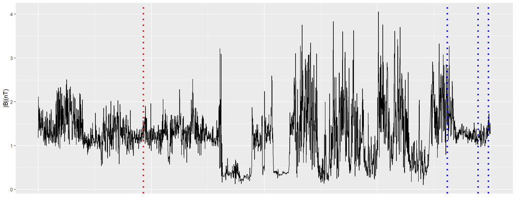

```r
###Finding all points in MAG 2005 between day 72 and 74

d1<-as.Date(72,origin="2005-01-01")
d2<-as.Date(73,origin="2005-01-01")
temp<-filter(joined_data,between(date,d1,d2))
bowShock<-filter(temp,type_cross=="BS")$TimeStamp
MagP<-filter(temp,type_cross=="MP")$TimeStamp

ggplot(data=temp, aes(x=TimeStamp , y=abs(BTotal.nT.))) +
  geom_line()+
  ylab("|B|(nT)")+
  xlab("Timestamp")+
  geom_vline(xintercept=bowShock, linetype="dotted",colour="blue",size=1.3)+
  geom_vline(xintercept=MagP, linetype="dotted",colour="red",size=1.3)+
  theme(axis.title.x=element_blank(),
        axis.text.x=element_blank(),
        axis.ticks.x=element_blank())
```

From the above figure the Red dotted line represents the time at which the Magnetopause region identified and blue dotted line represents the Bow Shock events.

### When cassini was in Inbound

This happened between the days 136 and 138 of the year 2005

#### Plotting Total Magnetic strength vs Time Stamp.

Also drawing a line that pointing the events.

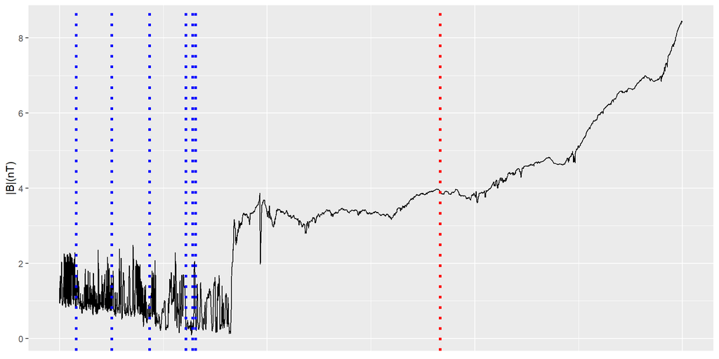

```r
###Finding all points in MAG 2005 between day 72 and 74

d1<-as.Date(136,origin="2005-01-01")
d2<-as.Date(138,origin="2005-01-01")
temp<-filter(joined_data,between(date,d1,d2))
bowShock<-filter(temp,type_cross=="BS")$TimeStamp
MagP<-filter(temp,type_cross=="MP")$TimeStamp

ggplot(data=temp, aes(x=TimeStamp , y=abs(BTotal.nT.))) +
  geom_line()+
  ylab("|B|(nT)")+
  xlab("Timestamp")+
  geom_vline(xintercept=bowShock, linetype="dotted",colour="blue",size=1.3)+
  geom_vline(xintercept=MagP, linetype="dotted",colour="red",size=1.3)+
  theme(axis.title.x=element_blank(),
        axis.text.x=element_blank(),
        axis.ticks.x=element_blank())
```

From the above figure the Red dotted line represents the time at which the Magnetopause region identified and blue dotted line represents the Bow Shock events.

## Plotting the trajectory of Cassini

In this plot we are trying to identify the positions at which all the events occurred.

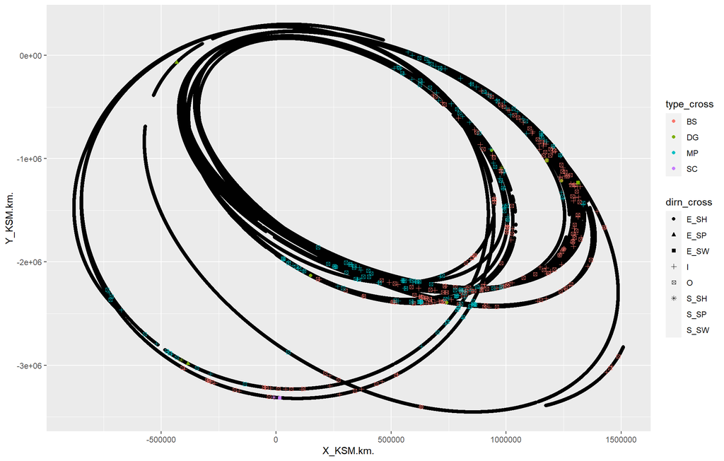

```r
ggplot(data_Wider, aes(x=X_KSM.km. , y=Y_KSM.km.))+
  geom_point(alpha=0.3)+
  geom_point(events_data, mapping =aes(x=X_KSM.km. , y=Y_KSM.km.,color=type_cross,shape=dirn_cross))
```

From this plot we can say that most of the events occurred in a particular region which faces the sun .

## Data Imbalance

### Proportion of Different directions in each event types.

In this plot we are trying to identify the proportion of Total events in the dataset (large).

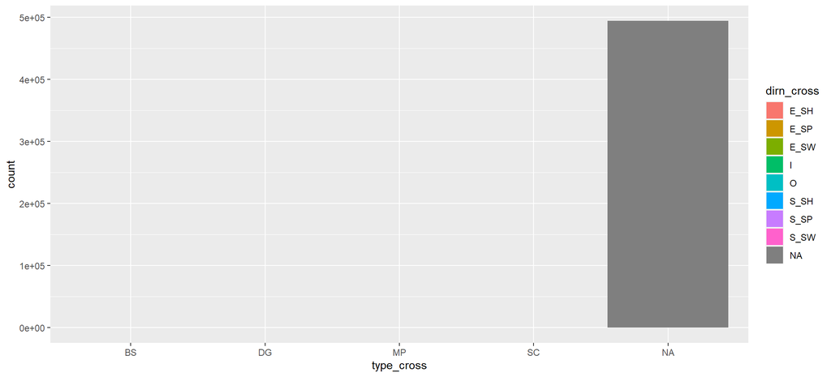

```r
ggplot(data = short_Data) +
  geom_bar(mapping = aes(x = type_cross, fill=dirn_cross))
```

### Proportion of each event types in Dataset.

In this plot we are trying to identify the Count of each events from an events only dataset.

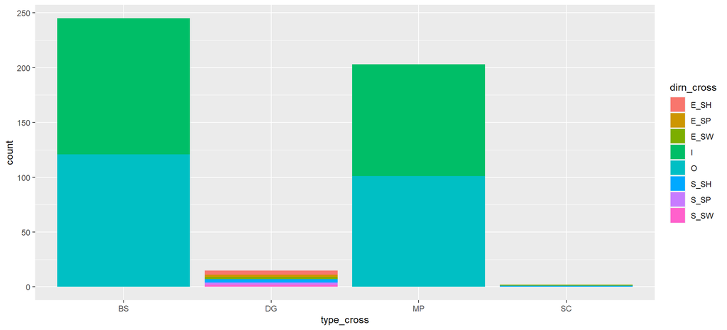

```r
ggplot(events_data, aes(type_cross, fill=dirn_cross )) +
  geom_bar(stat="count")
```

From the plot we can clearly say that BowShock events are recorded more times that Magneto pause.But the proportion of Inward or Outward direction is same for both.

### Proportion of Different directions in each event types.

In this plot we are trying to identify the proportion of each events in the dataset.

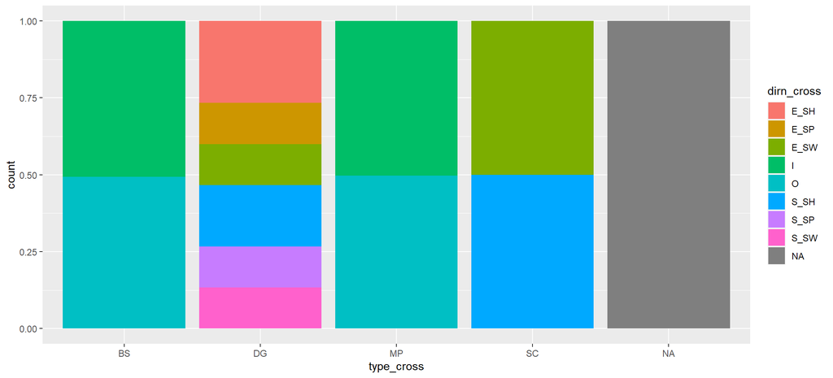

```r
ggplot(data = short_Data) +
  geom_bar(mapping = aes(x = type_cross, fill=dirn_cross) , position = "fill")
```

### Line graph of Average BTot(15 min Lag) vs BTOt. (Complete Datset)

In this plot we are trying to identify the pattern in which average value changes with the current value .

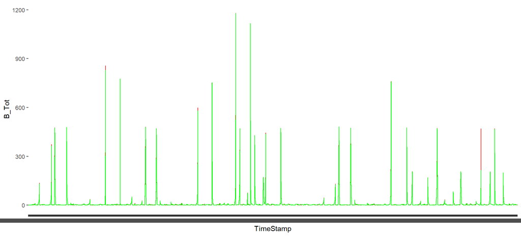

```r
ggplot(data=short_Data, aes(x=TimeStamp, group=1)) +
  geom_line(aes(y = B_Tot), color = "red")+
  geom_line(aes(y = Avg_Lag_BTot), color = "green")
```

In this plot we are trying to identify the pattern in which average 15 minute Lag value changes with the current value when an event occurs .

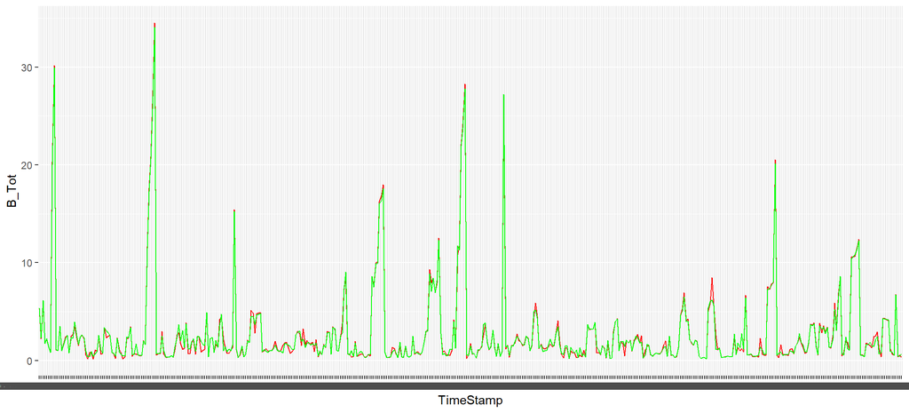

```r
ggplot(data=bs_avgData, aes(x=TimeStamp, group=1)) +
  geom_line(aes(y = B_Tot), color = "red")+
  geom_line(aes(y = Avg_Lag_BTot), color = "green")
```

In this plot we are trying to identify the pattern in which average 15 minute Lead value changes with the current value when an event occurs .  
**Orange :** Magneto Pause **Yellow :**Bow Shock

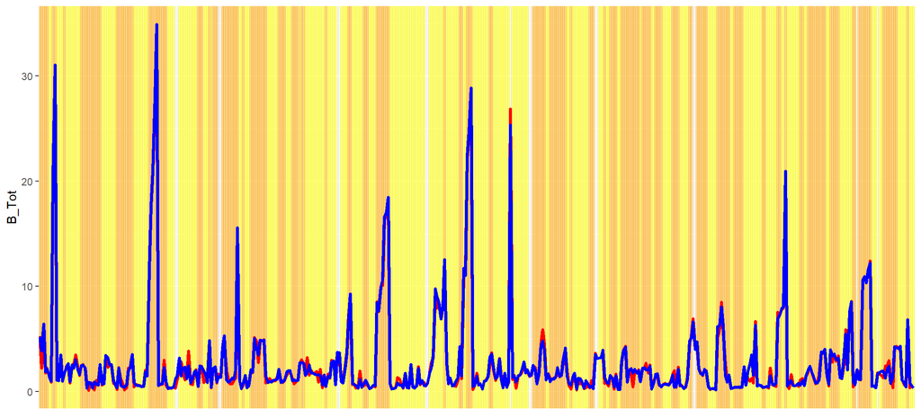

```r
bowShock<-filter(bs_avgData,type_cross=="BS")$TimeStamp
MagP<-filter(bs_avgData,type_cross=="MP")$TimeStamp

ggplot(data=bs_avgData, aes(x=TimeStamp, group=1)) +
    geom_vline(xintercept=bowShock,colour="yellow",size=1.3,alpha=0.4)+
  geom_vline(xintercept=MagP,colour="orange",size=1.3,alpha=0.4)+

  geom_line(aes(y = B_Tot), color = "red",size=1.3)+
  geom_line(aes(y = Avg_Lead_BTot), color = "blue",size=1.3)+
  theme(axis.title.x=element_blank(),
        axis.text.x=element_blank(),
        axis.ticks.x=element_blank())
```

Its is clear that BTot is higher in the region of Magnetopause and Avg values are linearly related to the Current value.